# Topic Modeling – STM

Asmik & Lisa – for Intro to NLP

April/May 2021

[figure not shown]

## Modeling Topics with an STM

This demo is about **topic modeling with a structural topic model (STM)**.

We show how to prepare the data for fitting an STM ([Roberts et al., 2016](https://scholar.princeton.edu/sites/default/files/bstewart/files/a_model_of_text_for_experimentation_in_the_social_sciences.pdf)), conduct the modeling process, and analyze the results.

```r
# Load required packages

library(data.table)
library(quanteda)
library(stm)
```

### Create `dfm` object

As in the static feature extraction demo, we convert our data to a `dfm`. However, we focus on slightly different tokens this time as we are now interested in identifying topical relations.

First, we get the **data** (the `path` variable again requiring individual adaptation):

```r
# path <- ... (individual file location)

twitter_corpus <- readRDS(sprintf("%s/twitter_corpus.RDS", path))

twitter_corpus
```

```
## Corpus consisting of 1,215 documents and 16 docvars.
## ABaerbock15156546001 :
## "Habe mir das Gro Ko-Sondierungspapier zu Klima nochmal genau..."
##
## ABaerbock15210084001 :
## "Auch weltweit sieht man, dass Angela Merkel s GroKo 3.0 nich..."
##
## ABaerbock15216341401 :
## "Der groessten globalen Herausforderung, der Klimakrise, 30 S..."
##
## ABaerbock15252349801 :
## "Wir brauchen eine andere Verkehrspolitik - weg von Benzinern..."
##
## ABaerbock15256297201 :
## "Das ist die Leistung von Hunderten Wahlkaempfern und Politik..."
##
## ABaerbock15283779001 :
## "Luise Amtsberg hat heute alles gesagt,was es zum Familiennac..."
##
## [ reached max_ndoc ... 1,209 more documents ]
```

We furthermore store the document texts in the docvars (which poses a redundancy in the `corpus` object but ensures the texts are not lost during conversion for the `dfm`).

```r
quanteda::docvars(twitter_corpus)$text <- quanteda::texts(twitter_corpus)
```

Now let’s **tokenize** our corpus in a way appropriate for topic modeling.

We assume that topical information is mostly carried by nouns and choose to remove all other words for document representation, attempting to eliminate noise that might distract our topic model. This is, of course, a simplification, but that’s life (of an analyst).

Luckily, nouns are pretty easy to identify by their leading capital letters in German (implicitly relying on MPs’ grammar skills and/or auto-correct, and accepting that this will also include non-nouns from the beginning of a sentence):

```r
# First, tokenize as usual

twitter_tokens <- quanteda::tokens(
  twitter_corpus,
  what = "word",
  remove_symbols = TRUE,
  remove_numbers = TRUE,
  remove_separators = TRUE,
  split_hyphens = TRUE,
  include_docvars = TRUE)
```

```r
# Stem

twitter_tokens <- quanteda::tokens_wordstem(
  twitter_tokens,
  language = "german")
```

```r
# Keep only tokens starting with a capital letter

twitter_tokens <- quanteda::tokens_keep(
  twitter_tokens,
  pattern = c("[:upper:]([:lower:])+"),
  valuetype = "regex",
  case_insensitive = FALSE)

# Lowercase afterwards

twitter_tokens <- quanteda::tokens_tolower(twitter_tokens)
```

For **stopwords** removal we retrace the steps taken in the static feature extraction:

```r
# Remove stopwords using our cleaning function from earlier

stopwords <- clean_and_stem(quanteda::stopwords(language = "de"))
stopwords <- stopwords[nchar(stopwords) > 0]
stopwords <- stringr::str_remove_all(
  stopwords,
  "kein(.)*|nicht")
stopwords <- c(
  stopwords,
  c("der", "die", "das", "was", "wer", "wie", "ich", "sie", "wir", "ihr"))

saveRDS(stopwords, sprintf("%s/stopwords.RDS", path))

twitter_tokens <- quanteda::tokens_remove(
  twitter_tokens,
  pattern = stopwords)

twitter_tokens <- quanteda::tokens_select(twitter_tokens, min_nchar = 3)

# Inspect

twitter_tokens
```

```
## Tokens consisting of 1,215 documents and 17 docvars.
## ABaerbock15156546001 :
##  [1] "gro"             "sondierungspapi" "klima"           "krass"
##  [5] "kyoto"           "protokoll"       "meilenstein"     "klimadiplomati"
##  [9] "frau"            "merkel"          "nachbess"
##
## ABaerbock15210084001 :
## [1] "angela"              "merkel"              "groko"
## [4] "paris"               "abkomm"              "dah"
## [7] "klimasofortprogramm"
##
## ABaerbock15216341401 :
## [1] "herausforder"      "klimakris"         "sek"
## [4] "std"               "regierungserklaer" "leerstell"
## [7] "koalitionsvertrag" "fuess"             "klimafolg"
##
## ABaerbock15252349801 :
## [1] "verkehrspolit" "benzin"        "diesel"        "mobilitaet"
## [5] "frag"          "luft"          "wohnung"       "strass"
##
## ABaerbock15256297201 :
## [1] "leistung"     "hundert"      "wahlkaempf"   "polit"        "land"
## [6] "mensch"       "konkret"      "polit"        "kommunalwahl"
##
## ABaerbock15283779001 :
##  [1] "luis"            "amtsberg"        "familiennachzug" "integration"
##  [5] "gefluechtet"     "perspektiv"      "zusammenleb"     "famili"
##  [9] "grundrecht"      "famili"          "groko"
##
## [ reached max_ndoc ... 1,209 more documents ]
```

Looking good, so convert to `dfm`:

```r
twitter_dfm <- quanteda::dfm(twitter_tokens)

twitter_dfm
```

```
## Document-feature matrix of: 1,215 documents, 4,923 features (99.81% sparse) and 17 docvars.
##                       features
## docs                   gro sondierungspapi klima krass kyoto protokoll
##   ABaerbock15156546001   1               1     1     1     1         1
##   ABaerbock15210084001   0               0     0     0     0         0
##   ABaerbock15216341401   0               0     0     0     0         0
##   ABaerbock15252349801   0               0     0     0     0         0
##   ABaerbock15256297201   0               0     0     0     0         0
##   ABaerbock15283779001   0               0     0     0     0         0
##                       features
## docs                   meilenstein klimadiplomati frau merkel
##   ABaerbock15156546001           1              1    1      1
##   ABaerbock15210084001           0              0    0      1
##   ABaerbock15216341401           0              0    0      0
##   ABaerbock15252349801           0              0    0      0
##   ABaerbock15256297201           0              0    0      0
##   ABaerbock15283779001           0              0    0      0
## [ reached max_ndoc ... 1,209 more documents, reached max_nfeat ... 4,913 more features ]
```

Unfortunately, as the above output tells us, our `dfm` is extremely **sparse** – tokens are not at all common across documents, which will pose a challenge to any topic model. This is actually not too surprising when we recall the extreme brevity of our Twitter documents.

*Side note*: if you run into this problem you might want to consider the option of pooling texts into larger documents (this can be achieved, for instance, calling `quanteda::dfm_group`). However, this is obviously a heavy simplification and leads to all documents that share the same grouping variable being assigned the same topic label.

What we will do to alleviate the sparsity problem at least to some extent is to condense the `dfm` to the most prominent features:

```r
# Eliminate less common features

twitter_dfm <- quanteda::dfm_select(
  twitter_dfm,
  names(quanteda::topfeatures(twitter_dfm, n = 300)))

twitter_dfm
```

```
## Document-feature matrix of: 1,215 documents, 300 features (98.78% sparse) and 17 docvars.
##                       features
## docs                   klima frau merkel groko klimakris diesel frag luft
##   ABaerbock15156546001     1    1      1     0         0      0    0    0
##   ABaerbock15210084001     0    0      1     1         0      0    0    0
##   ABaerbock15216341401     0    0      0     0         1      0    0    0
##   ABaerbock15252349801     0    0      0     0         0      1    1    1
##   ABaerbock15256297201     0    0      0     0         0      0    0    0
##   ABaerbock15283779001     0    0      0     1         0      0    0    0
##                       features
## docs                   strass polit
##   ABaerbock15156546001      0     0
##   ABaerbock15210084001      0     0
##   ABaerbock15216341401      0     0
##   ABaerbock15252349801      1     0
##   ABaerbock15256297201      0     2
##   ABaerbock15283779001      0     0
## [ reached max_ndoc ... 1,209 more documents, reached max_nfeat ... 290 more features ]
```

### Create prevalence formula

The special trait of the STM is its making use of s document-level **meta data**, so we need to specify which information to use here. In the `stm` function the corresponding argument is called `prevalence` and must be stated as a formula.

We will use the following meta variables (smooth effects defaulting to B-splines):

- `party` as a categorical variable,
- `bundesland` as a categorical variable,
- `unemployment_rate` as a smooth effect with 5 degrees of freedom, and
- `share_pop_migration` as a smooth effect with 5 degrees of freedom.

The resulting formula, `~ party + bundesland + s(unemployment_rate, df = 5) + s(share_pop_migration, df = 5)`, is perfectly disputable – this decision is up to domain knowledge and some trial-and-error.

```r
prevalence_formula <- as.formula(paste(
  "",
  "party + bundesland + s(unemployment_rate, df = 5) + s(share_pop_migration, df = 5)",
  sep = "~"))
```

Now we have one thing to pay attention to: the `stm` implementation cannot handle **missing data** in its prevalence variables. We must therefore exclude non-complete observations (alternatively, we could impute the missing values if it made sense and we had a meaningful imputation mechanism):

```r
twitter_dfm <- quanteda::dfm_subset(
  twitter_dfm,
  !is.na(party) & !is.na(bundesland) & !is.na(unemployment_rate) &
    !is.na(share_pop_migration))

twitter_dfm
```

```
## Document-feature matrix of: 1,199 documents, 300 features (98.78% sparse) and 17 docvars.
##                       features
## docs                   klima frau merkel groko klimakris diesel frag luft
##   ABaerbock15156546001     1    1      1     0         0      0    0    0
##   ABaerbock15210084001     0    0      1     1         0      0    0    0
##   ABaerbock15216341401     0    0      0     0         1      0    0    0
##   ABaerbock15252349801     0    0      0     0         0      1    1    1
##   ABaerbock15256297201     0    0      0     0         0      0    0    0
##   ABaerbock15283779001     0    0      0     1         0      0    0    0
##                       features
## docs                   strass polit
##   ABaerbock15156546001      0     0
##   ABaerbock15210084001      0     0
##   ABaerbock15216341401      0     0
##   ABaerbock15252349801      1     0
##   ABaerbock15256297201      0     2
##   ABaerbock15283779001      0     0
## [ reached max_ndoc ... 1,193 more documents, reached max_nfeat ... 290 more features ]
```

### Create `stm` object

We then convert our `dfm` to an `stm` object we can use in the structural topic model. This is super simple with `quanteda`:

```r
twitter_stm <- quanteda::convert(twitter_dfm, to = "stm")

summary(twitter_stm)
```

```
##           Length Class      Mode
## documents 1158   -none-     list
## vocab      300   -none-     character
## meta        17   data.frame list
```

### Fit STM

Time to fit the actual **model**.

While models learn all necessary *parameters* during training, *hyperparameters* need to be specified upfront. The most critical hyperparameter here is the number of topics, *K*. So how to find *K*?

Topic modeling being an unsupervised task (i.e., we do not have access to the ground truth), the quality of model output must ultimately be judged by human interpretability. We can seek some help from the data: `stm` offers a function that searches for the optimal *K* (still requiring a range of potential values!). Exactly what optimal means can be somewhat steered by the user. We will use the *held-out likelihood* option which creates an artificial supervised task: we mask a certain part of some of the documents and ask the model to complete them (note that the ground truth is known now). The more predictive power our model has, the higher the likelihood for the held-out words should be (for details see [Wallach et al., 2009](http://dirichlet.net/pdf/wallach09evaluation.pdf):

```r
# Conduct hyperparameter search

hyperparameter_search <- stm::searchK(
  documents = twitter_stm$documents,
  vocab = twitter_stm$vocab,
  data = twitter_stm$meta,
  K = c(3:10),
  prevalence = prevalence_formula,
  heldout.seed = 1, # seed for reproducibility
  max.em.its = 5, # number of iterations
  init.type = "Spectral",
  verbose = FALSE)
```

```r
# Fix optimal number of topics

(n_topics <- as.numeric(hyperparameter_search$results[
  which.max(hyperparameter_search$results[, "heldout"]), "K"]))
```

```
## [1] 4
```

Seems 4 topics is a good choice, so let’s fit the actual **model** now:

```r
# Fit STM

topic_model <- stm::stm(
  documents = twitter_stm$documents,
  vocab = twitter_stm$vocab,
  data = twitter_stm$meta,
  K = n_topics,
  prevalence = prevalence_formula,
  gamma.prior = "L1",
  seed = 1,
  max.em.its = 15,
  init.type = "Spectral",
  verbose = FALSE)
```

### Interpret results

The tricky thing about unsupervised topic modeling is the **interpretation** part. Statistical computations yield the results that best fit the data according to model assumptions but whether the found topics are considered meaningful is up to the human analyst.

Let’s see whether we can make any sense of the model output by

- inspecting the most characteristic words for each topic,
- printing the most representative document for a given topic, and
- generating a variety of visualizations.

For one, we can call `stm`’s `labelTopics` function which returns the top terms per topic according to different metrics (for details, best check the function documentation):

- Highest probability: which words are most likely to occur in a document of the given topic?
- FREX: which words occur both frequently and exclusively, i.e., serve to characterize and distinguish topics?
- Lift: which words occur most frequently if weighted by the inverse of their relative empirical frequency across the entire corpus?
- Score: which words show the largest difference between their (log) frequency in topic *k* and their average (log) frequency across all topics?

The `n` argument allows to specify how many words should be displayed. We go for 10:

```r
# Inspect results

(result_topic_modeling <- stm::labelTopics(topic_model, n = 10))
```

```
## Topic 1 Top Words:
##       Highest Prob: deutschland, recht, land, groko, kris, grenz, tuerkei, rechtsstaat, mehr, antwort
##       FREX: kris, groko, deutschland, pandemi, geld, miet, grenz, recht, million, entscheidung
##       Lift: panik, griechenland, schul, lockdown, pandemi, miet, kris, groko, entscheidung, konsequenz
##       Score: panik, deutschland, groko, recht, kris, grenz, pandemi, rechtsstaat, land, antwort
## Topic 2 Top Words:
##       Highest Prob: mensch, bundestag, zeit, merkel, regier, csu, seehof, tag, heut, welt
##       FREX: seehof, heut, welt, rassismus, gut, merkel, bundestag, mindestlohn, wahl, rent
##       Lift: mindestlohn, terror, rent, schwarz, seehof, kritik, vorsitz, muslim, kanzlerin, heut
##       Score: mindestlohn, mensch, bundestag, zeit, merkel, seehof, csu, heut, welt, regier
## Topic 3 Top Words:
##       Highest Prob: afd, cdu, corona, polit, arbeit, gruen, polizei, partei, menschenrecht, kein
##       FREX: gruen, thuering, polit, link, partei, antifa, seit, corona, arbeit, islam
##       Lift: doppelmoral, rot, antifa, abgeordnet, putin, gruen, russland, islam, praesident, thuering
##       Score: doppelmoral, cdu, polit, corona, gruen, afd, link, partei, arbeit, kein
## Topic 4 Top Words:
##       Highest Prob: bundesregier, jahr, frau, demokrati, dank, klimaschutz, zukunft, europa, gewalt, berlin
##       FREX: dank, glueckwunsch, frau, einsatz, zukunft, herzlich, wissenschaft, koalition, zahl, signal
##       Lift: mitt, for, einsatz, glueckwunsch, stuttgart, wissenschaft, koalition, signal, herzlich, dank
##       Score: mitt, dank, demokrati, frau, bundesregier, klimaschutz, glueckwunsch, zukunft, europa, einsatz
```

We can also access the word lists directly if we are particularly interested in results w.r.t a specific metric:

```r
t(result_topic_modeling$frex)
```

```
##       [,1]           [,2]          [,3]       [,4]
##  [1,] "kris"         "seehof"      "gruen"    "dank"
##  [2,] "groko"        "heut"        "thuering" "glueckwunsch"
##  [3,] "deutschland"  "welt"        "polit"    "frau"
##  [4,] "pandemi"      "rassismus"   "link"     "einsatz"
##  [5,] "geld"         "gut"         "partei"   "zukunft"
##  [6,] "miet"         "merkel"      "antifa"   "herzlich"
##  [7,] "grenz"        "bundestag"   "seit"     "wissenschaft"
##  [8,] "recht"        "mindestlohn" "corona"   "koalition"
##  [9,] "million"      "wahl"        "arbeit"   "zahl"
## [10,] "entscheidung" "rent"        "islam"    "signal"
```

NB: Our results here are not very glorious. We have already seen the extreme sparsity of the `dfm`, and with documents that are pretty dissimilar a topic model can only do so much. This is also a consequence of our training data design: we have labels for relatively few, extremely short documents from a bunch of different authors. In reality, scraping gives us access to much larger amounts of data.

Next, let’s take another look at our topics by a more visually appealing means:

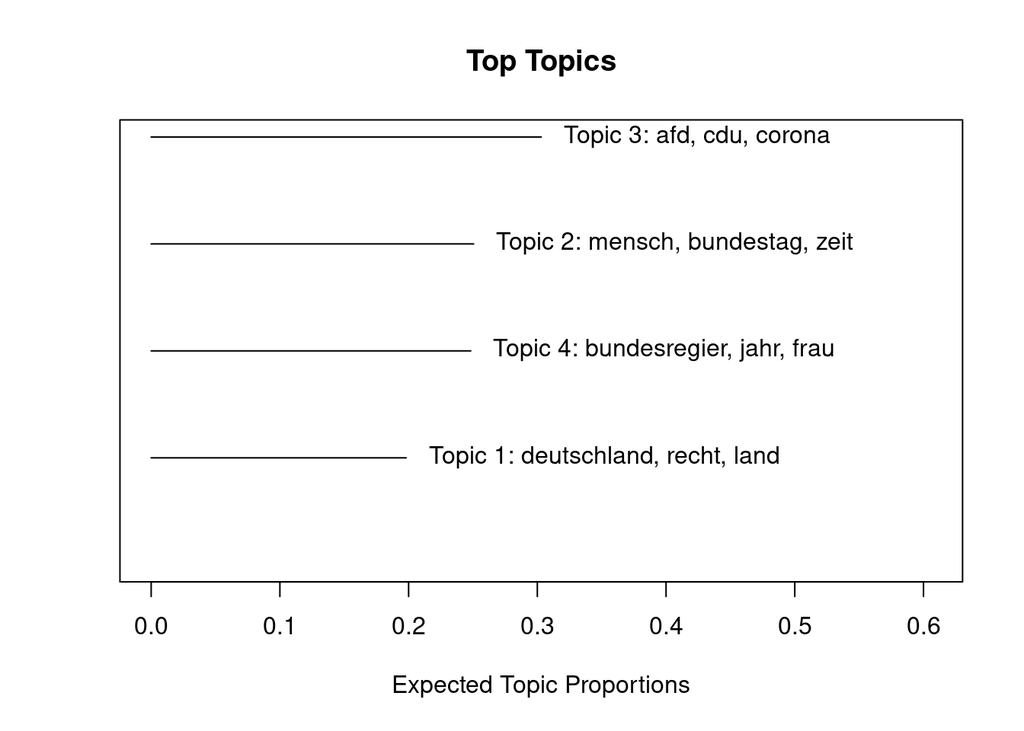

```r
plot(topic_model, type = "summary")
```

We can also plot **word clouds** displaying the most prominent words per topic (size indicating the probability of a word occurring in a document of the given topic):

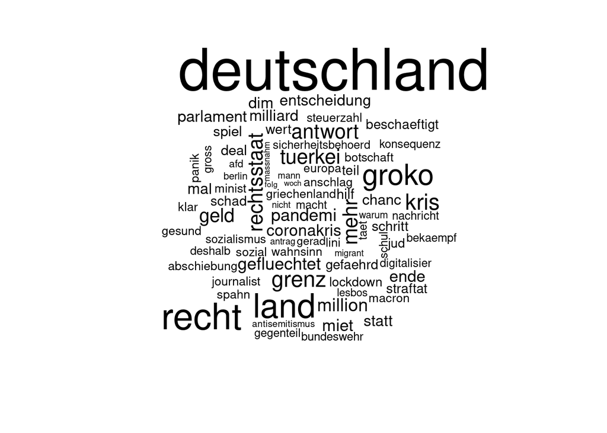

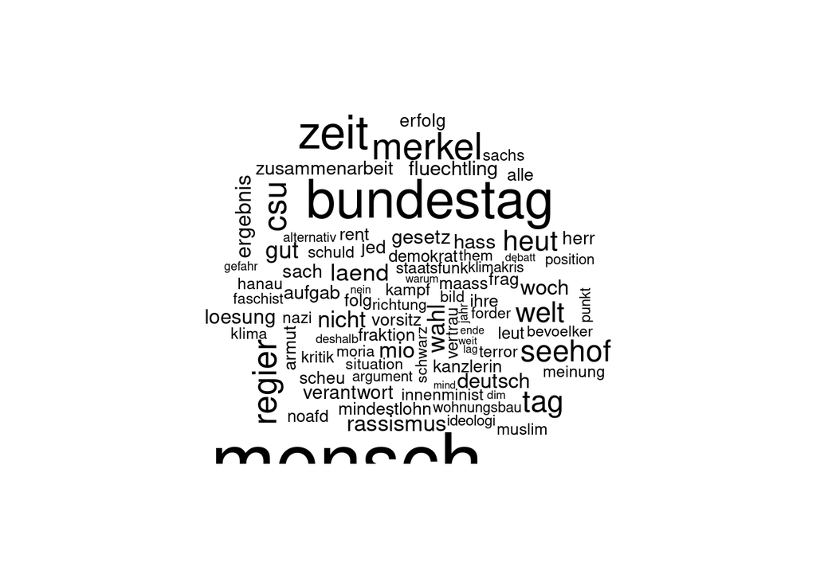

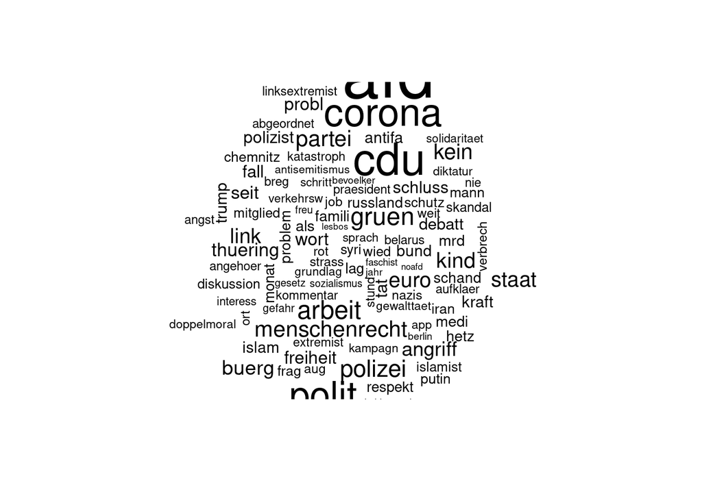

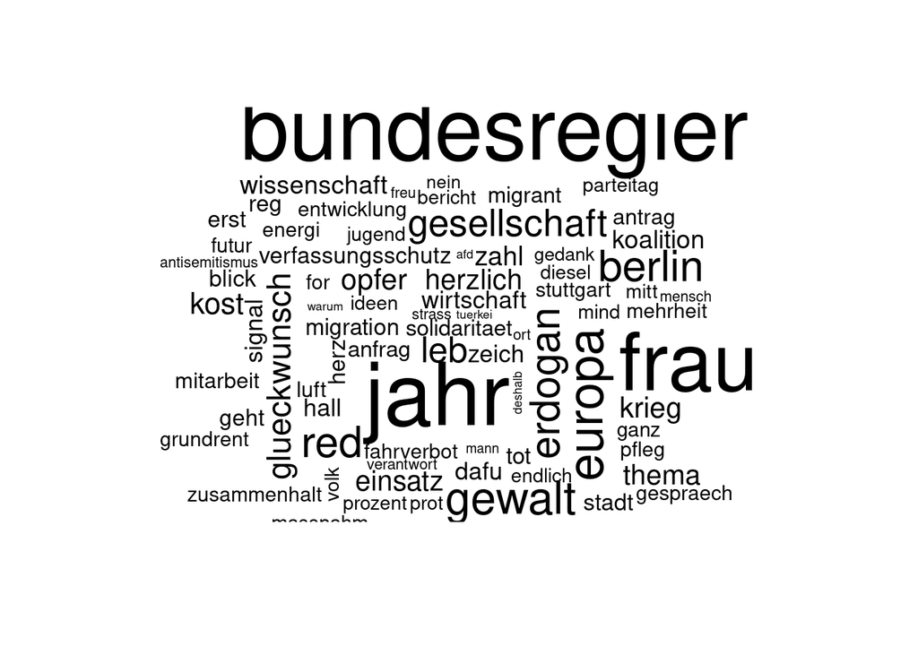

```r
invisible(lapply(seq_len(n_topics), function(i) stm::cloud(topic_model, topic = i)))
```

Finally, let’s see the most representative documents for each topic, i.e., the tweets with the highest topic probability:

```r
lapply(seq_len(n_topics), function(i) {
  stm::findThoughts(
    model = topic_model,
    texts = twitter_stm$meta$text,
    topics = i,
    n = 2)$docs[[1]]})
```

```
## [[1]]
## [1] "Mehr Straftaten + mehr gewalttaetige Migranten + mehr als 10.000 Salafisten = Sicheres Deutschland. Das Einzige, das in Deutschland sicher ist wie das Amen in der Kirche, ist die Ueberheblichkeit der politischen Klasse."
## [2] "Behoerden haben syrischen Gefaehrder nicht lueckenlos observiert. Dieser schwere Fehler ist aufzuarbeiten. Klar ist aber: Beobachtung ist kein geeignetes Mittel, Gefaehrder unschaedlich zu machen. Selbst beobachtete Gefaehrder lassen sich nicht bei Ausfuehrung ihrer Anschlaege stoppen."
##
## [[2]]
## [1] "Seehofer redet im Bundestag von Naechstenliebe und ueberlaesst im selben Atemzug Menschen in Not sich selbst. Das Mindeste waere es, endlich den Kommunen die Aufnahme zu ermoeglichen! Moria Wir Haben Platz"
## [2] "Was nicht zueinander passt: Krokodilstraenen ueber den Umgang mit Andrea Nahles weinen und dann bei Malu Dreyer, und genauso weitermachen. Ich bin ihnen sehr dankbar, dass sie in einer sehr schwierigen Situation Verantwortung fuer die spd uebernehmen."
##
## [[3]]
## [1] "Gruene Extremisten halten Hambacher Forst besetzt, attackieren Polizei und legen wie Vietcong Tunnelsysteme an. Politische Unterstuetzung erhalten sie von den Gruenen. Schluss mit dieser Doppelmoral, auch Gruene muessen staatliches Gewaltmonopol respektieren!"
## [2] "Antifa ist Gewalt Antifa ist Hass Antifa ist Sozialismus Antifa ist Terrorismus Antifa ist der terroristische Arm von SED und Bekenntnis zur Antifa macht klar: diese Parteien sind der parlamentarische Armdes Linksterrorismus"
##
## [[4]]
## [1] "Super Initiative, super Rede! zu unserem Antrag fuer ein soziales Europa: Wir brauchen mehr Zusammenhalt in der , denn nur gemeinsam sind wir stark. Und staerkeres Europa geht nur mit mehr Zusammenhalt Solidaritaet"
## [2] "-Glueckwunsch an aktiv fuer den Kohleausstieg, ich konnte und viele andere eurer VertreterInnen erleben ob im Bundestag oder im Hambi. Danke fuer euren wahnsinnigen Einsatz! Herzlichen Glueckwunsch zum taz panter2020 Preis!! hambibleibt"
```

Using this visual support (and probably playing around with, e.g., the number of features to include in the `dfm` and the number of topics) we would now try to give our topic some decent names.

### Assign documents to topics

So `stm` has thrown a lot of words at us from which we are hopefully able to infer meaningful topics, but which documents actually belong to which topic? The model output provides us with a vector of topic probabilities for each document, meaning we can **label** the tweets by picking the topic for which they have the highest respective probability:

```r
# Extract topic probabilities together with topic IDs and discard docnum

topic_probs <- stm::make.dt(topic_model)[
  , doc_id := names(twitter_stm$documents)
  ][, docnum := NULL]

topic_probs[sample(topic_probs[, .I], 5)]
```

```
##       Topic1    Topic2    Topic3    Topic4                     doc_id
## 1: 0.1845032 0.2521544 0.3780500 0.1852924    mueller_sepp15886573801
## 2: 0.1517988 0.1856061 0.5404195 0.1221756 Martin_Hess_AfD15941187001
## 3: 0.1967556 0.2758847 0.3281626 0.1991971     norbert_mdb15609262201
## 4: 0.1573959 0.1768963 0.2216394 0.4440683    katjakipping15429903001
## 5: 0.2270346 0.2792316 0.2994396 0.1942942 MarcBernhardAfD15728828401
```

```r
# Get topic with highest score per document

topic_cols <- names(topic_probs)[startsWith(names(topic_probs), "Topic")]

topic_probs[
  , `:=` (
    max_topic_score = max(.SD, na.rm = TRUE),
    topic_label = which.max(.SD)),
  .SDcols = topic_cols,
  by = doc_id]

topic_probs[sample(topic_probs[, .I], 5)]
```

```
##       Topic1    Topic2    Topic3    Topic4                     doc_id
## 1: 0.2710746 0.1561289 0.1238118 0.4489848 JBrandenburgFDP15829845001
## 2: 0.1250096 0.4394698 0.2452353 0.1902853      edrossmann15910920601
## 3: 0.1180359 0.4891803 0.1770004 0.2157834        kleikert15446922601
## 4: 0.2525005 0.1292979 0.4865941 0.1316075 Martin_Hess_AfD15619650001
## 5: 0.1520429 0.1689663 0.3478590 0.3311319 Beatrix_vStorch16034461801
##    max_topic_score topic_label
## 1:       0.4489848           4
## 2:       0.4394698           2
## 3:       0.4891803           2
## 4:       0.4865941           3
## 5:       0.3478590           3
```

For mapping the topic labels back to the original tweets append them to the docvars…

```r
# Extract docvars

twitter_docvars <- data.table::as.data.table(
  cbind(
    doc_id = quanteda::docid(twitter_corpus),
    quanteda::docvars(twitter_corpus)),
  key = "doc_id")

# Append topic labels and remove irrelevant columns

twitter_docvars <- topic_probs[
  twitter_docvars, on = "doc_id"
    ][, c(topic_cols) := NULL]

twitter_docvars[sample(twitter_docvars[, .I], 5)]
```

```
##                        doc_id max_topic_score topic_label      last_name
## 1:  GoeringEckardt16001751001       0.3792726           3 Göring-Eckardt
## 2:     b_riexinger15408928801       0.2935914           3      Riexinger
## 3:  GoeringEckardt16070101801       0.3550243           1 Göring-Eckardt
## 4:       KatjaMast15832571401       0.3248543           2           Mast
## 5: Martin_Hess_AfD16082181601       0.5518424           3           Hess
##    first_name                     wahlkreis_name  party         bundesland
## 1:     Katrin Erfurt – Weimar – Weimarer Land II gruene         Thueringen
## 2:      Bernd                       Stuttgart II  linke Baden-Wuerttemberg
## 3:     Katrin Erfurt – Weimar – Weimarer Land II gruene         Thueringen
## 4:      Katja                          Pforzheim    spd Baden-Wuerttemberg
## 5:     Martin                        Ludwigsburg    afd Baden-Wuerttemberg
##    unemployment_rate share_pop_migration        username followers_count
## 1:               6.8                 6.6  GoeringEckardt          174395
## 2:               5.0                38.6     b_riexinger           38584
```

[output cut: 27 more lines]

…and, lastly, feed this information back into the original corpus object to save it for further usage:

```r
# Insert info back into corpus

twitter_corpus_with_topics <- twitter_corpus

quanteda::docvars(twitter_corpus_with_topics) <- as.data.frame(twitter_docvars)

# Save

saveRDS(
  twitter_corpus_with_topics,
  sprintf("%s/twitter_corpus_with_topics.RDS", path))
```

**So that’s how to model topics with an `stm`! Even though our training corpus is not easily clustered into topics, you hopefully got some idea how to handle this process code-wise. And then, we just do not always get lucky with such tasks in a sense that they can be expected to produce meaningful output all the time** ¯|*(ツ)*/¯